# DSsim - Truncation Distances

Kieran Richards

2016-08-15

# Using DSsim to investigate Truncation Distances

## 1. Introduction

Distance Sampling is a process in which an area is surveyed so that the size of a population within an area can be estimated. Distances from a set of transects to observed objects are recorded and these data are used to model a detection function. From this the population in the whole area can be estimated.

### 1.1 Introduction to DSsim

DSsim is a tool which simulates this process. DSsim splits the process into three stages. First it generates a population. DSsim then simulates the distance sampling survey. This is done using a detection function and a survey design. For the final stage DSsim analyses the data from the survey.

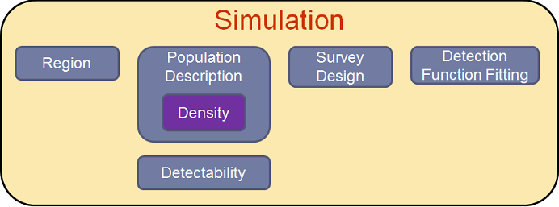

Figure 1 - A simulation is composed of several other objects including the region and a survey design. If you wish to change one of these components you will also have to remake the simulation afterwards to update the simulation.

When fitting a detection function the data is often truncated at some distance from the transect. The number of detections will decrease at larger distances from the transect and observations can lead to poorer precision in the estimate of abundance by distorting the shape of the detection function. It has been suggeste to truncate the data where the estimated probability of detection is 0.15 (Buckland et al. 2001) however this has been a topic of much discussion.

This vignette explores how truncation distances affect the accuracy and precision of the estimates of a population size. This will be used to provide examples of how to use DSsim to make and run simulations as well as how to analyse the results. Simulations will be run with truncation distances at different multiples of $\sigma$ as shown in Figure 2. For a half normal detection function the suggested truncation distance is approximately 2$\sigma$ and for a hazard rate detection function with shape parameter 4 this is approximately 1.5$\sigma$.

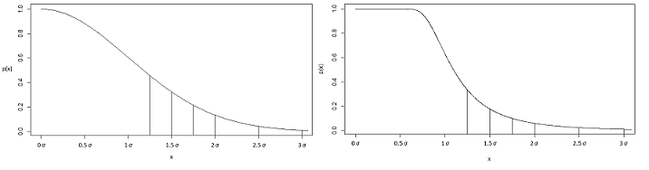

Figure 2 - A half normal and hazard rate distributions with vertical lines showing the truncation distances used in this vignette

## 2. Methods

### 2.1 Setup

The package needs to be loaded and also the seed has been set so that the results in this vignette can be easily reproduced. The package *shapefiles* will also be required.

```r
library(DSsim)
library(shapefiles)
set.seed(4321)
```

## 2.2 Making the Simulation Components

### 2.2.1 Region

The first part of the simulation is the region. For the investigation a simple 20,000m by 5,000m rectangular region will be used. This requires a shapefile which describes the region. To estimate the abundance in the region DSsim needs the area of the region. DSsim calculates this automatically using *areapl* from the *splancs* package (Rowlingson and Diggle 2015). If this is not suitable then DSsim can be provided with an area that has been calculated elsewhere using the area argument of *make.region*. The following code creates the region and plots it in Figure 3:

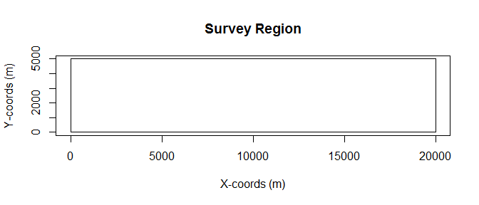

Figure 3 - A plot of the study region

```r
region.shapefile <- read.shapefile("Study_ar") #DSsim assumes there is a shapefile called this in the R working directory
region <- make.region(region.name = "Survey Region",
                      units = "m",
                      shapefile = region.shapefile)
plot(region)
```

### 2.2.2 Population

The second part of the simulation is the population description which needs a description of the population density. For the investigation we will use a constant density over the whole surface. Furthermore when the simulation later generates a population during the simulation it will do so using a known population size so the value of this constant is not important. The *x.space* and *y.space* arguments describe the grid points on the density surface. As the density surface will be the same everywhere this does not matter too much, however if the density surface varies then it may be wise to decrease the spacing between grid points to allow finer detail on the surface. This code produces the density object and plots it over the region in Figure 4:

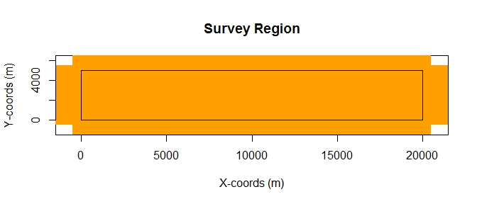

Figure 4 - A plot of the study region with a heat map showing the population density overlayed

```r
pop.density <- make.density(region = region,
                            x.space = 1000,
                            y.space = 1000,
                            constant = 1)
plot(pop.density, plot.units = "m", style = "blocks")
plot(region, add = TRUE)
```

Now that a description of the density across the region is available the population description can be put together from which the simulation will generate a population. A fixed value for the population size, N=250, is given. We have chosen 250 because with the detection function we have used this results in around 60 observations, the minimum number of recomendations usually recommended for distance sampling surveys. This will ensure that any effects of truncation distance are not obscured by using a large population size. If this is not given then DSsim will generate the population using the average density across the region.

```r
pop.description <- make.population.description(region.obj = region,
                                               density.obj = pop.density,
                                               N = 250,
                                               fixed.N = TRUE)
```

### 2.2.3 Defining Detectability

Next the components that will be used to simulate the observation process need to be made. The first of these is the known detection function. The key function can be one of *hn*(half normal) or *hr*(hazard rate). Here a half normal with scale parameter 100 and a observation truncation distance of 500 is used:

```r
sigma = 100
detect <- make.detectability(key.function = "hn",
                             scale.param = sigma,
                             truncation = 500)
```

### 2.2.4 Design

When carrying out a distance sampling survey we create a survey based on a design. Currently this cannot be done using DSsim and must be done using other software. Here we have done this using the Distance for Windows software (Thomas et al. 2010). A systematic parallel line transect design with a spacing of 1000m between transects was used. The transects were orientated so that they were running across the narrower dimension of the study region, this resulted in 20 transects per survey. The recommended minimum number of transects for line transect studies is from 10-20 (Buckland et al. 2001).

```r
parallel.design <- make.design(transect.type = "Line",
                               design.details = c("Parallel","Systematic"),
                               region.obj = region,
                               path = "shapefiles")
```

### 2.2.5 Analysis

Finally the simulation needs to know how to analyse the results of the observation process. A list of models which can be fitted to the distance data will be made and the simulation will select the one with the minimum criteria value. In the truncation distances investigation the simulation was forced to pick a half normal model. The first truncation distance that was used was 1.25$\sigma$:

```r
ddf.analyses <- make.ddf.analysis.list(dsmodel = list(~cds(key = "hn", formula = ~1)),
                                       method = "ds",
                                       truncation = 125)
```

### 2.2.5.1 Model Selection

In the real world we do not know the shape of the detection function and must use model selection criteria to decide between models of different shape. Here we use the AIC to decide between a hazard rate model and a half normal model but the BIC can also be used:

```r
ddf.analyses.aic <- make.ddf.analysis.list(dsmodel = list(~cds(key = "hn", formula = ~1), ~cds(key = "hr", formula = ~1)),
                                           method = "ds",
                                           criteria = "AIC",
                                           truncation = 125)
```

### 2.2.6 Simulations

Now that all of the components of the simulation have been made the simulation is made by putting them all together:

```r
simtrunc125 <- make.simulation(reps = 999,
                               single.transect.set = FALSE,
                               region.obj = region,
                               design.obj = parallel.design,
                               population.description.obj = pop.description,
                               detectability.obj = detect,
                               ddf.analyses.list = ddf.analyses)
```

As simulations can take a long time to run it is often worth checking that the setup is right first. The first thing that should be checked is that a population is being correctly generated within the region:

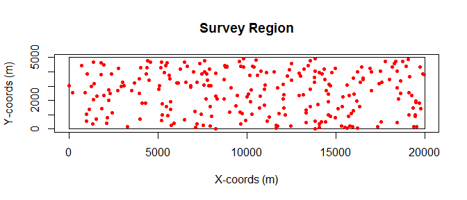

Figure 5 - A plot of the study region with an example population displayed

```r
pop <- generate.population(simtrunc125)
plot(region)
plot(pop)
```

Next it should be checked that the transects have been placed correctly:

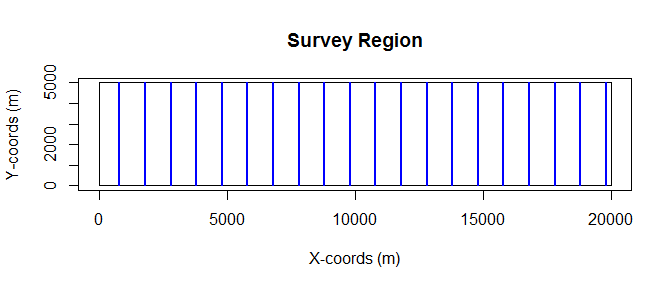

Figure 6 - A plot of the study region with an example set of transect lines overlayed

```r
transects <- generate.transects(simtrunc125)
plot(region)
plot(transects, col = 4, lwd = 2)
```

The observation process can be quickly simulated once to ensure that it is working correctly. The distance from each object to the transects will be used to calculate the probability of the object being detected. Then Bernoulli trials with these probabilities of success are carried out for each of the objects. The observed objects are marked as blue points, the unobserved objects are the red points:

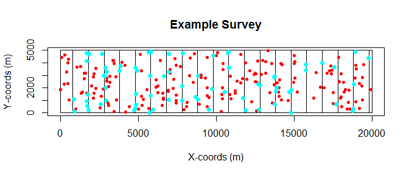

Figure 7 - A plot of the study region showing a completed observation process. The red dots are the unobserved objects while the blue dots are the observed objects

```r
eg.survey <- create.survey.results(simtrunc125)
plot(eg.survey)
```

This distance data can also be viewed in a histogram to get an idea of what the fitted detection function will look like:

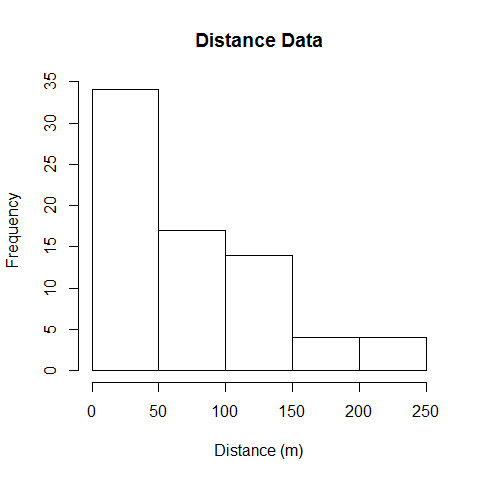

Figure 8 - A histogram showing the distances from the transects at which objects were observed

```r
dist.data <- get.distance.data(eg.survey)
hist(dist.data$distance, xlab = "Distance (m)", main = "Distance Data")
```

If the setup has been done right the simulation can now be run but first we will reset the seed so that subsequent simulations use the same population:

```r
set.seed(4321)
simtrunc125 <- run(simtrunc125)
```

More simulations are then needed for the investigation; each using different truncation distances for the analysis. After changing a part of the simulation it is necessary to make the simulation again to update it:

```r
Trun.dists <- c(1.25*sigma, 1.5*sigma, 1.75*sigma, 2*sigma, 2.5*sigma, 3*sigma)
sims <- vector("list", length(Trun.dists))
sims[[1]]<-simtrunc125
for(i in 2:6){
  set.seed(4321)
  ddf.analyses <- make.ddf.analysis.list(dsmodel = list(~cds(key = "hn", formula = ~1)),
                                         method = "ds", truncation = Trun.dists[[i]])
  sim <- make.simulation(reps = 999,
                         single.transect.set = FALSE,
                         region.obj = region,
                         design.obj = parallel.design,
                         population.description.obj = pop.description,
                         detectability.obj = detect,
                         ddf.analyses.list = ddf.analyses)
  sim  <- run(sim)
  sims[[i]]<-sim
}
save(sims, file = "~/GitHub/DSsim/DSsim/data/truncationResults.rda")
```

Since these simulations take a long time to run we do not run them here. However we have included the results of these simulations in the package so we will load them so that we can interperet them in this vignette. We have also loaded some results from simulations where DSsim was allowed to choose between a half normal and a hazard rate key for the detection function using both the AIC and the BIC criteria as well as some where the true detection function had a hazard rate key:

```r
load(file = "~/GitHub/DSsim/DSsim/data/truncationResults.rda")
load(file = "~/GitHub/DSsim/DSsim/data/truncationResultsAIC.rda")
load(file = "~/GitHub/DSsim/DSsim/data/truncationResultsBIC.rda")
load(file = "~/GitHub/DSsim/DSsim/data/truncationResultsAIChrkey.rda")
load(file = "~/GitHub/DSsim/DSsim/data/truncationResultsBIChrkey.rda")
```

## 3. Extracting the Results

The results of simulations can be viewed by calling *summary* on the simulation object:

```r
#Not run
summary(sims[[1]])
```

This investigation involves running multiple simulations so instead we will write some functions to extract information from the simulation objects. It is not necessary to understand how these functions work, details are provided here for interested readers however the reader could just run the code and skip to the next section if they prefer.

We use a switch statement to allow the user to specify the required information and then return the value from the appropriate slot in the simulation object:

```r
extract.info <- function(simulation, info.name){
  switch(info.name,
         N = simulation@population.description@N,
         reps = simulation@reps,
         truncation.distance = simulation@ddf.analyses[[1]]@truncation,
         n = simulation@results$individuals$summary[1,4,1000],
         estimated.abundance = simulation@results$individuals$N[1,1,1000],
         mean.se = simulation@results$individuals$N[1,2,1000],
         percentage.bias = 100*((simulation@results$individuals$N[1,1,1000]
                                 - simulation@population.description@N)
                                /simulation@population.description@N),
         RMSE = sqrt(sum((simulation@results$individuals$N[1,1,1:simulation@reps]
                          - simulation@population.description@N)**2, na.rm = TRUE)/simulation@reps))
}
```

## 4. The Results

Once the results have been extracted the function *kable* from the package *knitr* will be used to table the results:

```r
library(knitr)
```

```r
Trunc.Dist <- lapply(sims, extract.info, info.name = "truncation.distance")
n          <- lapply(sims, extract.info, info.name = "n")
Est.Abund  <- lapply(sims, extract.info, info.name = "estimated.abundance")
mean.se    <- lapply(sims, extract.info, info.name = "mean.se")
Perc.Bias  <- lapply(sims, extract.info, info.name = "percentage.bias")
RMSE.orig  <- lapply(sims, extract.info, info.name = "RMSE")
```

Then the results must be combined into a data frame to be tabled:

```r
simulation.data = cbind(Trunc.Dist = Trunc.Dist,
                        n=n,
                        Est.Abund = Est.Abund,
                        mean.se = mean.se,
                        Perc.Bias = Perc.Bias,
                        RMSE=RMSE.orig)
```

Finally the results can be tabled. The align argument has been used to centre the results in each column and the digits argument has been used to specify the number of decimal places in each column.

```r
table<-kable(simulation.data,
             digits = 2,
             col.names = c("$Trunc Dist$", "$n$", "$Mean \\hat{N}$", "$SE$", "$\\% Bias$", "$RMSE$"),
             align = c('c', 'c', 'c', 'c', 'c', 'c', 'c') )

print(table, floating=TRUE, NA.string="NA", caption = "Simulation Results", caption.placement="top", table.placement="!h", latex.environments="center", type = "html")
```

| $Trunc Dist$ | $n$ | $Mean \hat{N}$ | $SE$ | $\% Bias$ | $RMSE$ |
| --- | --- | --- | --- | --- | --- |
| 125 | 49.14629 | 251.5252 | 50.27452 | 0.6100973 | 46.94973 |
| 150 | 53.92492 | 251.1372 | 46.98734 | 0.4548662 | 44.39477 |
| 175 | 57.25125 | 250.7555 | 44.50556 | 0.3021901 | 41.19397 |
| 200 | 59.44144 | 250.4585 | 42.81947 | 0.1834105 | 39.3205 |
| 250 | 61.47548 | 250.8003 | 40.83563 | 0.3201123 | 37.62996 |
| 300 | 62.06707 | 251.1221 | 39.97558 | 0.448854 | 36.18861 |

```r
table<-kable(simulation.data,
             digits = 2,
             col.names = c("$Trunc Dist$", "$n$", "$Mean \\hat{N}$", "$SE$", "$\\% Bias$", "$RMSE$"),
             align = c('c', 'c', 'c', 'c', 'c', 'c', 'c') )

print(table, floating=TRUE, NA.string="NA", caption = "Simulation Results", caption.placement="top", table.placement="!h", latex.environments="center", type = "html")
```

[output not shown]

```r
table<-kable(simulation.modelselect.hr.data,
             digits = 2,
             col.names = c("$Trunc Dist$", "$n$", "$Mean \\hat{N}$", "$SE$", "$\\% Bias$", "$RMSE$"),
             align = c('c', 'c', 'c', 'c', 'c', 'c', 'c') )

print(table, floating=TRUE, NA.string="NA", caption = "Simulation Results", caption.placement="top", table.placement="!h", latex.environments="center", type = "html")
```

| $Trunc Dist$ | $n$ | $Mean \hat{N}$ | $SE$ | $\% Bias$ | $RMSE$ |
| --- | --- | --- | --- | --- | --- |
| 125 | 57.68569 | 266.476 | 47.73509 | 6.59042 | 45.73968 |
| 180 | 68.42042 | 270.6292 | 43.90062 | 8.251683 | 49.73679 |
| 210 | 71.31431 | 270.1662 | 42.35778 | 8.066471 | 48.76268 |
| 240 | 73.61562 | 270.6061 | 41.95103 | 8.242427 | 47.48822 |
| 300 | 76.16917 | 267.4224 | 40.9718 | 6.968958 | 43.60596 |
| 360 | 77.5976 | 264.1392 | 40.53781 | 5.65568 | 41.67139 |
| 125 | 57.68569 | 268.304 | 49.87488 | 7.321616 | 46.71823 |
| 125 | 57.68569 | 268.304 | 49.87488 | 7.321616 | 46.71823 |
| 125 | 57.68569 | 268.304 | 49.87488 | 7.321616 | 46.71823 |
| 125 | 57.68569 | 268.304 | 49.87488 | 7.321616 | 46.71823 |
| 125 | 57.68569 | 268.304 | 49.87488 | 7.321616 | 46.71823 |
| 125 | 57.68569 | 268.304 | 49.87488 | 7.321616 | 46.71823 |

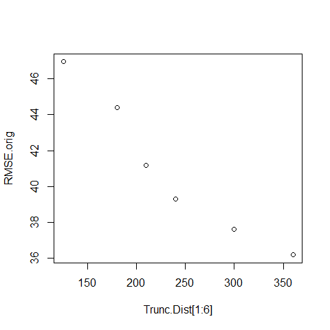

Figure 9 - There is a clear downwards trend in RMSE as less data is truncated

```r
plot(Trunc.Dist[1:6], RMSE.orig)
```

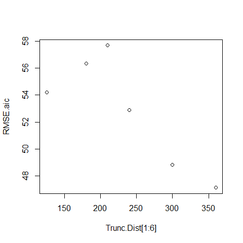

```r
plot(Trunc.Dist[1:6], RMSE.aic)
```

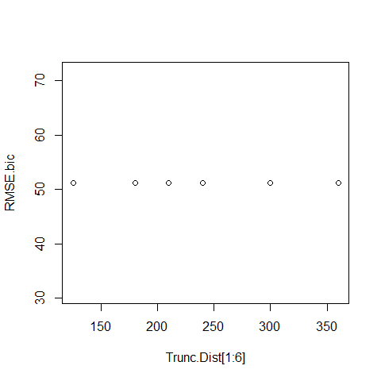

```r
plot(Trunc.Dist[1:6], RMSE.bic)
```

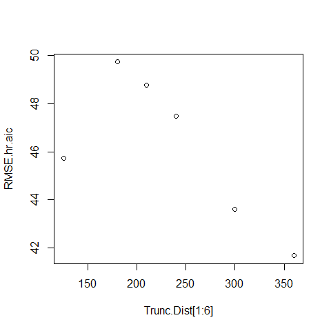

```r
plot(Trunc.Dist[1:6], RMSE.hr.aic)
```

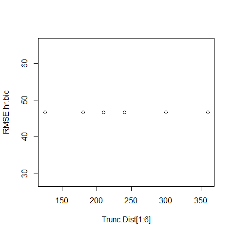

```r
plot(Trunc.Dist[1:6], RMSE.hr.bic)
```

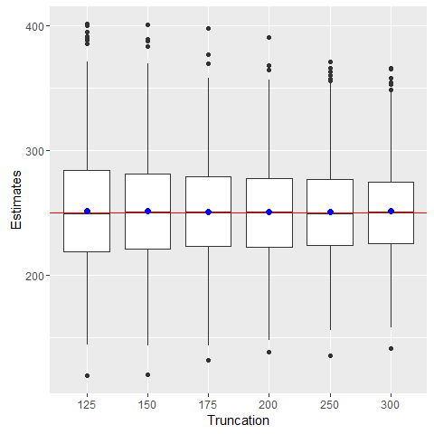

```r
library(ggplot2)
data = data.frame(Truncation = factor(rep(c(125, 150, 175, 200, 250, 300), each=999)), Estimates = c(sims[[1]]@results$individuals$N[1,1,1:999], sims[[2]]@results$individuals$N[1,1,1:999], sims[[3]]@results$individuals$N[1,1,1:999], sims[[4]]@results$individuals$N[1,1,1:999], sims[[5]]@results$individuals$N[1,1,1:999], sims[[6]]@results$individuals$N[1,1,1:999]))

ggplot(data, aes(x = Truncation, y = Estimates)) + geom_boxplot() + geom_hline(yintercept = 250, color = "red", size = 0.5) + stat_summary(fun.y = mean, geom="point", size = 2, color = "blue")
```

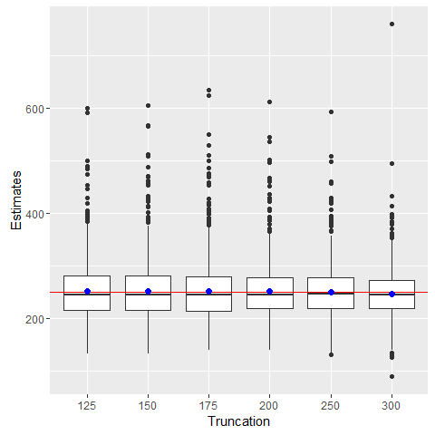

Figure 11

```r
library(ggplot2)
data = data.frame(Truncation = factor(rep(c(125, 150, 175, 200, 250, 300), each=999)), Estimates = c(sims.aic[[1]]@results$individuals$N[1,1,1:999], sims.aic[[2]]@results$individuals$N[1,1,1:999], sims.aic[[3]]@results$individuals$N[1,1,1:999], sims.aic[[4]]@results$individuals$N[1,1,1:999], sims.aic[[5]]@results$individuals$N[1,1,1:999], sims.aic[[6]]@results$individuals$N[1,1,1:999]))

ggplot(data, aes(x = Truncation, y = Estimates)) + geom_boxplot() + geom_hline(yintercept = 250, color = "red", size = 0.5) + stat_summary(fun.y = mean, geom="point", size = 2, color = "blue")
```

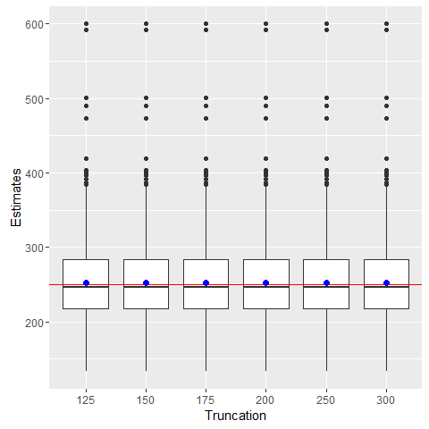

Figure 12

```r
library(ggplot2)
data = data.frame(Truncation = factor(rep(c(125, 150, 175, 200, 250, 300), each=999)), Estimates = c(sims.bic[[1]]@results$individuals$N[1,1,1:999], sims.bic[[2]]@results$individuals$N[1,1,1:999], sims.bic[[3]]@results$individuals$N[1,1,1:999], sims.bic[[4]]@results$individuals$N[1,1,1:999], sims.bic[[5]]@results$individuals$N[1,1,1:999], sims.bic[[6]]@results$individuals$N[1,1,1:999]))

ggplot(data, aes(x = Truncation, y = Estimates)) + geom_boxplot() + geom_hline(yintercept = 250, color = "red", size = 0.5) + stat_summary(fun.y = mean, geom="point", size = 2, color = "blue")
```

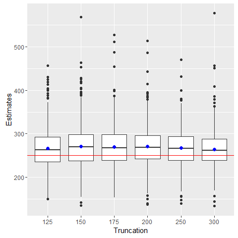

Figure 13

```r
library(ggplot2)
data = data.frame(Truncation = factor(rep(c(125, 150, 175, 200, 250, 300), each=999)), Estimates = c(sims.hr.aic[[1]]@results$individuals$N[1,1,1:999], sims.hr.aic[[2]]@results$individuals$N[1,1,1:999], sims.hr.aic[[3]]@results$individuals$N[1,1,1:999], sims.hr.aic[[4]]@results$individuals$N[1,1,1:999], sims.hr.aic[[5]]@results$individuals$N[1,1,1:999], sims.hr.aic[[6]]@results$individuals$N[1,1,1:999]))

ggplot(data, aes(x = Truncation, y = Estimates)) + geom_boxplot() + geom_hline(yintercept = 250, color = "red", size = 0.5) + stat_summary(fun.y = mean, geom="point", size = 2, color = "blue")
```

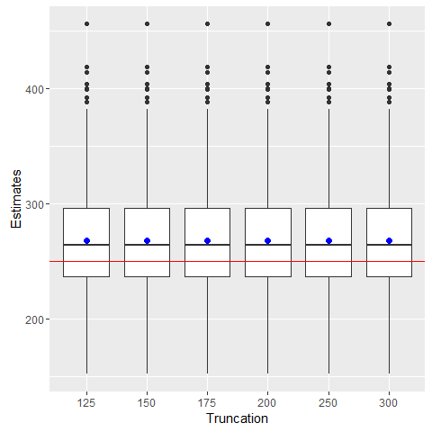

Figure 14

```r
library(ggplot2)
data = data.frame(Truncation = factor(rep(c(125, 150, 175, 200, 250, 300), each=999)), Estimates = c(sims.hr.bic[[1]]@results$individuals$N[1,1,1:999], sims.hr.bic[[2]]@results$individuals$N[1,1,1:999], sims.hr.bic[[3]]@results$individuals$N[1,1,1:999], sims.hr.bic[[4]]@results$individuals$N[1,1,1:999], sims.hr.bic[[5]]@results$individuals$N[1,1,1:999], sims.hr.bic[[6]]@results$individuals$N[1,1,1:999]))

ggplot(data, aes(x = Truncation, y = Estimates)) + geom_boxplot() + geom_hline(yintercept = 250, color = "red", size = 0.5) + stat_summary(fun.y = mean, geom="point", size = 2, color = "blue")
```

## 5. The Conclusions

Changing the truncation distance did not lead to big differences in the % Bias however there was a clear trend in precision. Since each simulation was successfully run the same number of times we could use the RMSE as a meaningful comparison to combine the two and found that truncating less data was better by this metric. However, differences were small even at this small sample size and so truncation distance should not be a big concern at the analysis stage. It should also be noted that the observers for the survey should not be given a truncation distance because if they see something just beyond this distance they may be tempted to record it at the truncation distance which will lead to heaping at this distance.

## 6. References

Buckland, Stephen T, David R Anderson, Kenneth P Burnham, David L Borchers, and Len Thomas. 2001. *Introduction to Distance Sampling*. Estimating Abundance of Biological Populations. Oxford University Press, Oxford, UK.

Rowlingson, Barry, and Peter Diggle. 2015. *Splancs: Spatial and Space-Time Point Pattern Analysis*. https://CRAN.R-project.org/package=splancs.

Thomas, Len, Stephen T Buckland, Eric A Rexstad, Jeffrey L Laake, Samantha Strindberg, Sharon L Hedley, Jon R B Bishop, Tiago A Marques, and Kenneth P Burnham. 2010. “Distance software: design and analysis of distance sampling surveys for estimating population size.” *Journal of Applied Ecology* 47 (1): 5–14.